# Assignment 3: Progression of Coronary Artery Calcification in Normal Subjects

Milan Filipovic

April 21, 2021

**Exercise**

Complete a Biostatistics Consulting Worksheet for the following study. Your worksheet should include:

- Statement of statistical hypothesis(es)
- Assessment of assumptions used in any statistical inference
- Analysis of data set. (You will need to retrieve from our website one of two data files: “cac.dta” and “cac.txt”.)
- Interpretation of results in terms of original research hypothesis so that a non-statistician would be able to explain results to colleagues.

## Question 1

*1.* Based on the introduction and variable list, complete the following sections of a Biostatistics Consulting Worksheet:

1. Date & Client Information
2. Purpose
3. Background & references
4. Descriptions

**Date**: 04/23/2021

**Client Information**:

- Name: H.C. Yoon, A. Emerick, J Hill and J Goldin
- Department: Department of Diagnostic Imaging, Kaiser Moanalua Medical Center and the Department of Radiological Sciences, UCLA
- Phone: (310) 267-8785
- Name of principal investigator: H.C. Yoon, A. Emerick, J Hill and J Goldin from the Department of Diagnostic Imaging, Kaiser Moanalua Medical Center and the Department of Radiological Sciences, UCLA

**Purpose**

- Statement of research hypothesis(es):
  - To test the hypothesis that the rate of CAC progression is gender specific being greater in men then women.
- Statement of statistical hypothesis(es):
  - The rate of CAC progression in men is greater than it is in women
  - Null hypothesis: The rate of change in calcium volume score (CVS) between men and women is statistically significantly different

**Background & references**:

- Recent reports indicate that electron-beam computed tomography (EBCT) can document the presence and monitor the progression of atherosclerotic CAC in the general adult population as well as in those with increased cardiovascular risk (1-3).
- EBCT can measure changes in the extent of CAC in adults treated with lipid-lowering agents. *Interpretation of the clinical significance of different coronary artery calcium scores in the same patient is dependent on several factors:
  - Measurement variation
  - Expected rate of progression of coronary calcium
1. Maher JE; Bielak LF; Raz JA; Sheedy II PF; Schwartz RS; Peyser PA. Progression of Coronary Artery Calcification: A Pilot Study. Mayo Clin Proc 1999; 74:347-355. 1999.
2. Goodman WG, Goldin J, Kuizon BD, Yoon C, Gales B, Sider D, Wang Y, Chung J, Emerick A, Greaser L, Elashoff RM, Salusky IB. Coronary-artery calcification in young adults with end-stage renal disease who are undergoing dialysis. N Engl J Med. 2000;342:1478-83.
3. Budoff MJ; Lane KL; Bakhsheshi H; Mao S; Grassmann BO; Friedman BC; Brundage BH. Rates of Progression of Coronary Calcium by Electron Beam Tomography. Am J Cardiol 2000; 86:8-11.

**Descriptions**:

- Study design: Retrospective study
- Population(s): Adults who experience the progression of athersclerotic CAC
- Sample(s): 217 asymptomatic subjects who underwent at least two electron-beam computed tomography (EBCT) for detection of CAC as a part of a clinical screening program.
  - Asymptomatic defined as no history of ischemic heart disease
  - No abnormal electrocardiogram, stress test, coronary angiogram, and no prior myocardial infarction or coronary bypass surgery
- Dependent variable(s):
  - vol1
  - vol2
  - days
- Independent variable(s):
  - sex
  - age

```
##      nid sex age vol1 vol2 days
##   1:   1   0  36  110  158  694
##   2:   2   0  37    0    0  691
##   3:   3   0  44    0    0  927
##   4:   4   0  44    0    0  719
##   5:   5   0  46    0    0 1545
##  ---
## 213: 213   0  55   34  137 1057
## 214: 214   1  70  397  548  641
## 215: 215   0  63    9   13 1012
## 216: 216   1  67  282  387  714
## 217: 217   1  67   63   82  943
```

Checking Data for cleanliness

Variable Descriptions

```r
#Haven stores the stata labels in as variable attributes. We can access them using map_chr from the purrr package
#cac %>% map_chr(~attributes(.)$label)
```

Note about CAC score taken from radiopaedia: CAC score of 1-112: low risk with a relative risk ratio of 1.9 (95 CI: 1.3-2.8) CAC score of 100-400: moderate risk with a relative risk ratio of 4.3 (95% CI:3.1-6.1) CAC score of 401-999: high risk with a relative risk ratio of 7.2 (95% CI:5.2-9.9) Source: [link](https://radiopaedia.org/articles/calcium-volume-score?lang=us#:~:text=CAC%20score%20of%201%2D112,%25%20CI%3A5.2%2D9.9))

```r
cac_tble %>% mutate(gender = ifelse(cac_tble$sex == 1, "men","women"), vol_change = vol2-vol1) %>%
  select(-sex, -nid) %>%
  tbl_summary(by = gender, missing_text = "Missing",
              label = list(age ~ "Age First Scanned",
                           vol1 ~ "CVS at First Visit",
                           vol2 ~ "CVS at Second Visit",
                           days ~ "Days Between Visits",
                           vol_change ~ "Change in CVS")) %>%
  add_p(test = list(all_continuous() ~ "t.test")) %>%
  bold_labels() %>%
  add_overall() %>%
  modify_header(label ~ "**Participant Characteristics**")
```

| **Participant Characteristics** | **Overall**, N = 217<sup>1</sup> | **men**, N = 114<sup>1</sup> | **women**, N = 103<sup>1</sup> | **p-value**<sup>2</sup> |
| --- | --- | --- | --- | --- |
| Age First Scanned | 57 (50, 65) | 54 (46, 64) | 61 (52, 66) | 0.001 |
| CVS at First Visit | 21 (0, 175) | 96 (8, 252) | 0 (0, 42) | 0.004 |
| CVS at Second Visit | 40 (0, 223) | 117 (7, 366) | 4 (0, 85) | 0.004 |
| Days Between Visits | 701 (475, 992) | 700 (471, 983) | 705 (512, 1,011) | 0.4 |
| Change in CVS | 5 (0, 49) | 14 (0, 75) | 0 (0, 17) | 0.025 |

<sup>*1*</sup> Median (IQR) <sup>*2*</sup> Welch Two Sample t-test

Next Visualize key predictors

```r
cac_tble <- cac_tble %>%
  mutate(gender = ifelse(cac_tble$sex == 1, "men","women"), vol_change = vol2-vol1)

summary(cac_tble)
```

```
##       nid           sex              age             vol1
##  Min.   :  1   Min.   :0.0000   Min.   :26.00   Min.   :   0.0
##  1st Qu.: 55   1st Qu.:0.0000   1st Qu.:50.00   1st Qu.:   0.0
##  Median :109   Median :1.0000   Median :57.00   Median :  21.0
##  Mean   :109   Mean   :0.5253   Mean   :57.16   Mean   : 175.9
##  3rd Qu.:163   3rd Qu.:1.0000   3rd Qu.:65.00   3rd Qu.: 175.0
##  Max.   :217   Max.   :1.0000   Max.   :85.00   Max.   :3138.0
##       vol2             days           gender            vol_change
##  Min.   :   0.0   Min.   : 245.0   Length:217         Min.   :-246.00
##  1st Qu.:   0.0   1st Qu.: 475.0   Class :character   1st Qu.:   0.00
##  Median :  40.0   Median : 701.0   Mode  :character   Median :   5.00
##  Mean   : 227.4   Mean   : 761.5                      Mean   :  51.57
##  3rd Qu.: 223.0   3rd Qu.: 992.0                      3rd Qu.:  49.00
##  Max.   :4291.0   Max.   :1941.0                      Max.   :1311.00
```

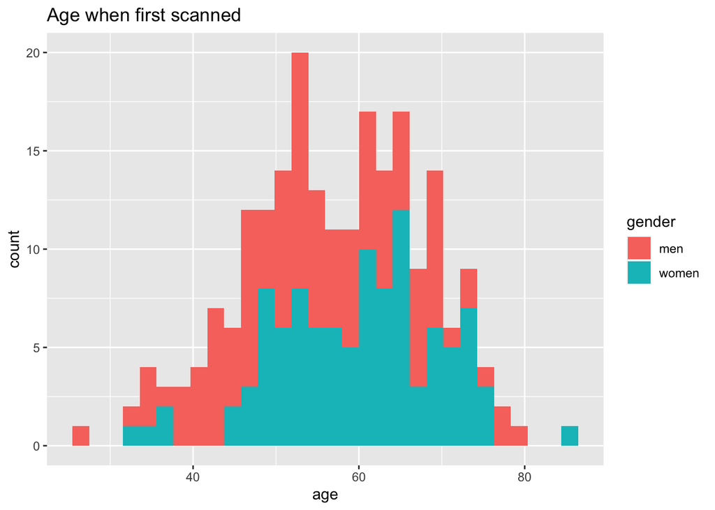

```r
cac_tble %>% ggplot(mapping = aes(x = age)) +
  geom_histogram(mapping = aes(x = age, fill = gender)) +
  labs(title = "Age when first scanned")
```

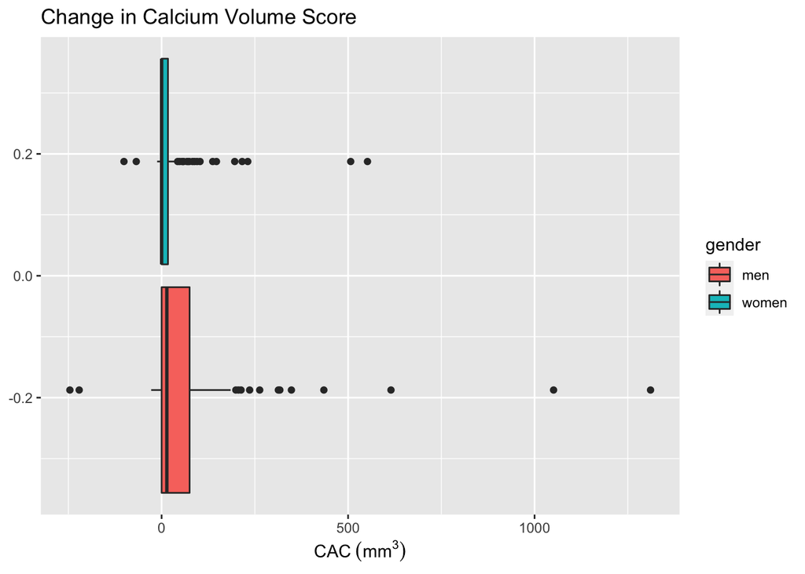

```r
cac_tble %>% ggplot() +
  geom_boxplot(mapping = aes(x = vol_change, fill = gender)) +
  labs(x = expression(CAC~(mm^3)), title = "Change in Calcium Volume Score")
```

Age appears to be normally distributed, wheareas volume change appears to be right skewed. Some transformation should be applied to normalize the data, and outliers should be examined for validity.